# Coronavirus v Čechách

# Základní statistiky

## Testy

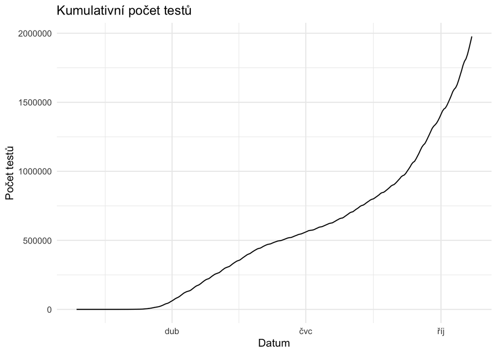

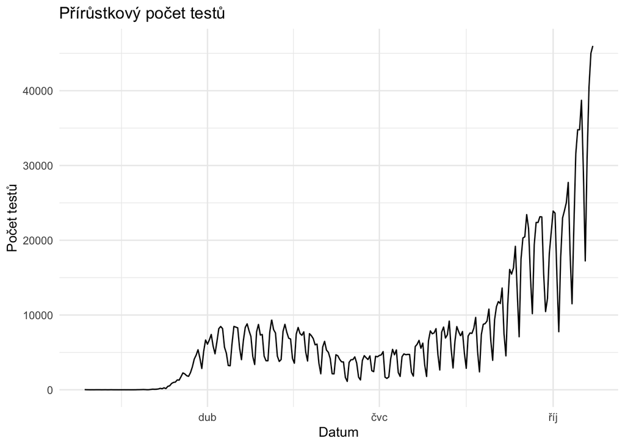

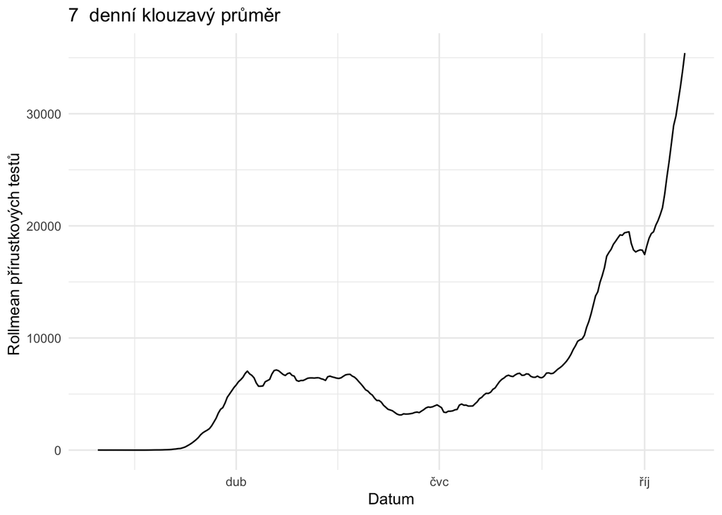

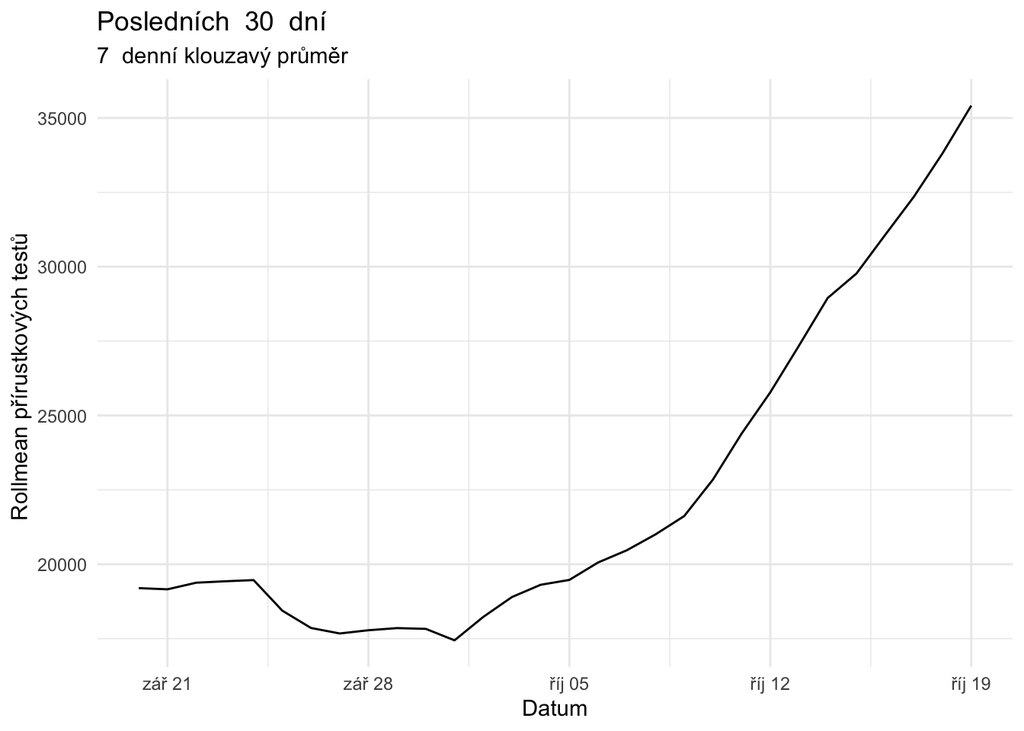

## Pozitivní případy

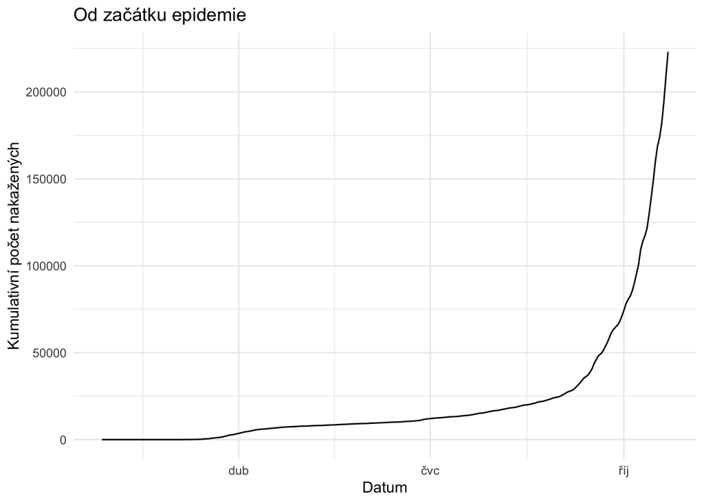

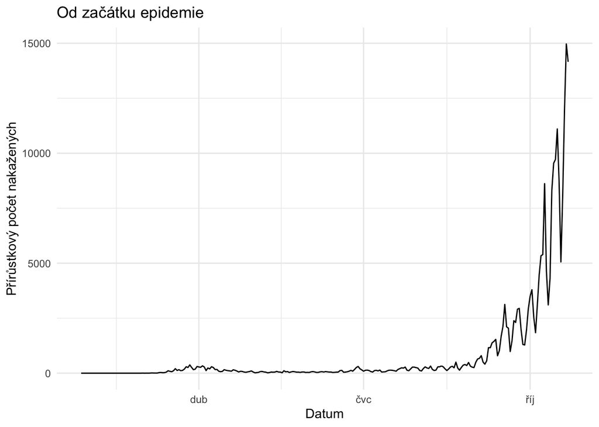

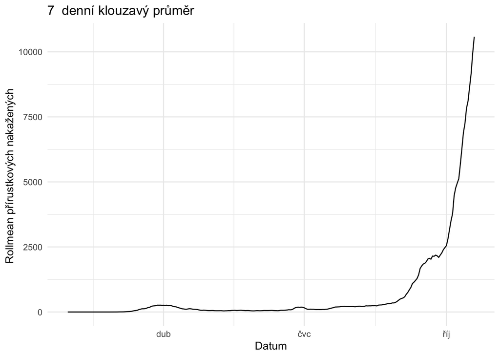

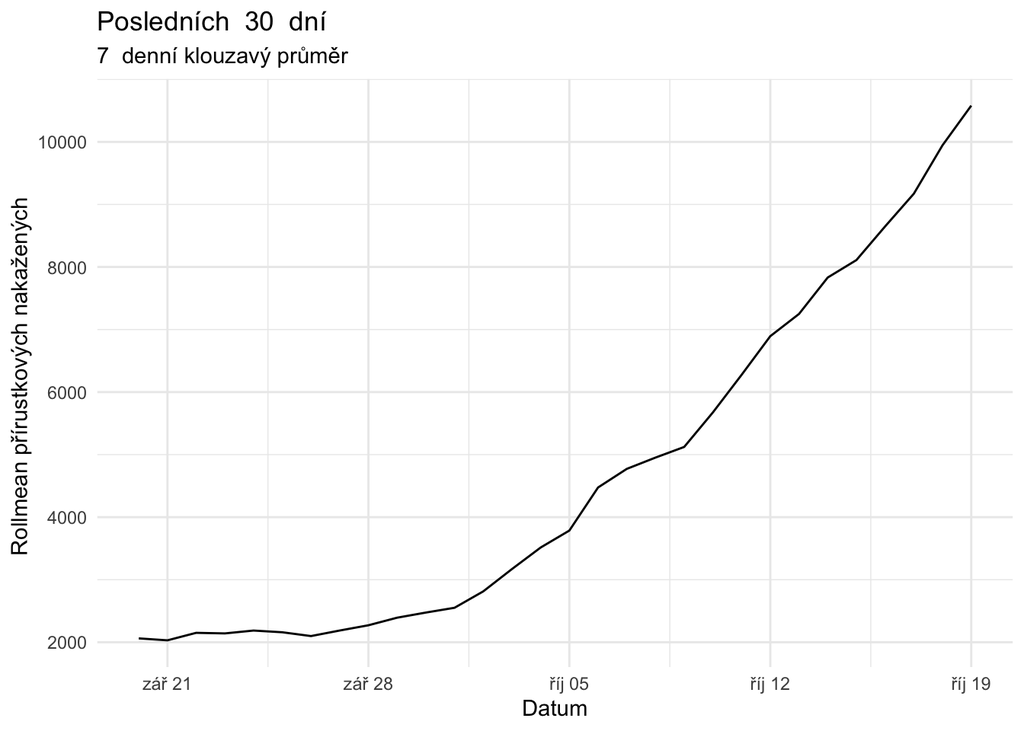

## Podíl pozitivních testů

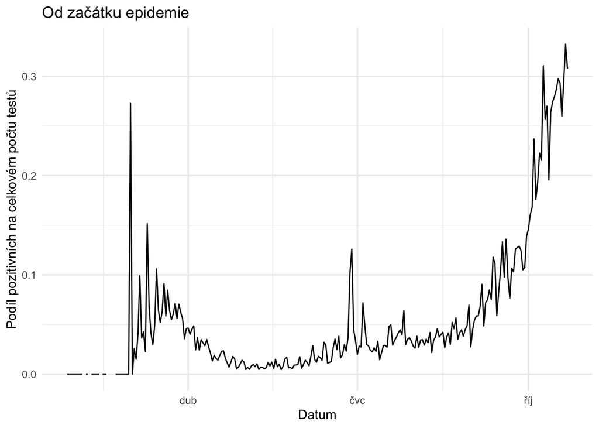

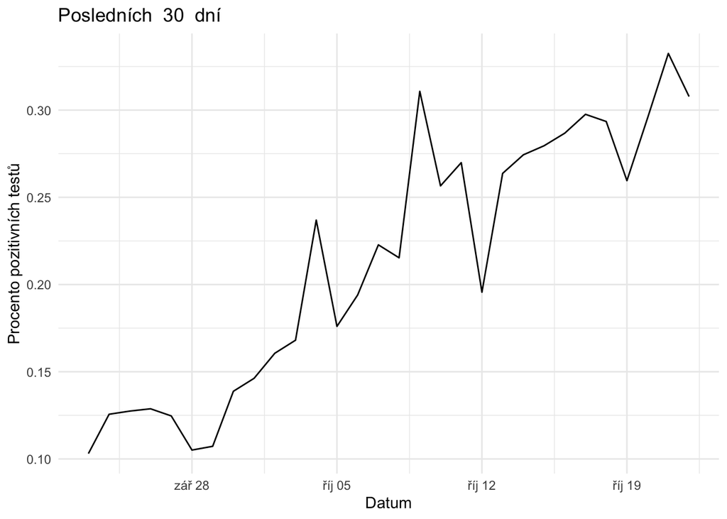

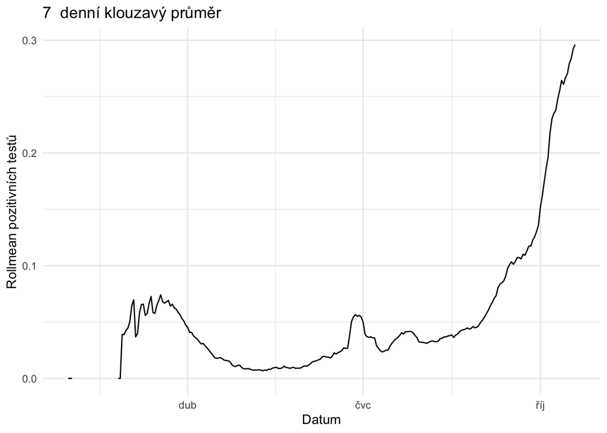

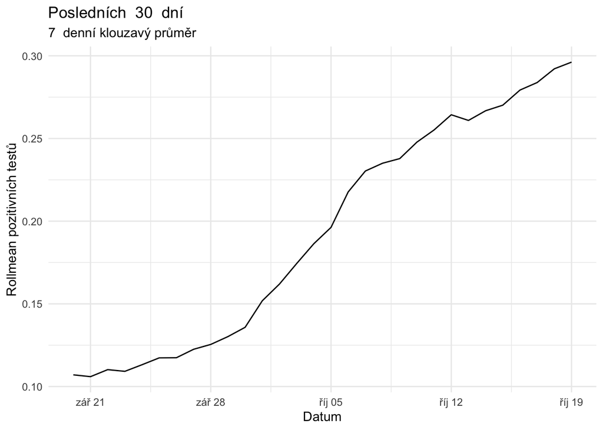

Podíl pozitivních testů na celkovém počtu od začátku epidemie je `11.284` %.

Podíl pozitivních testů na celkovém počtu za posledních 30 dní je `23.13` %.

# Modely

## Linearní model

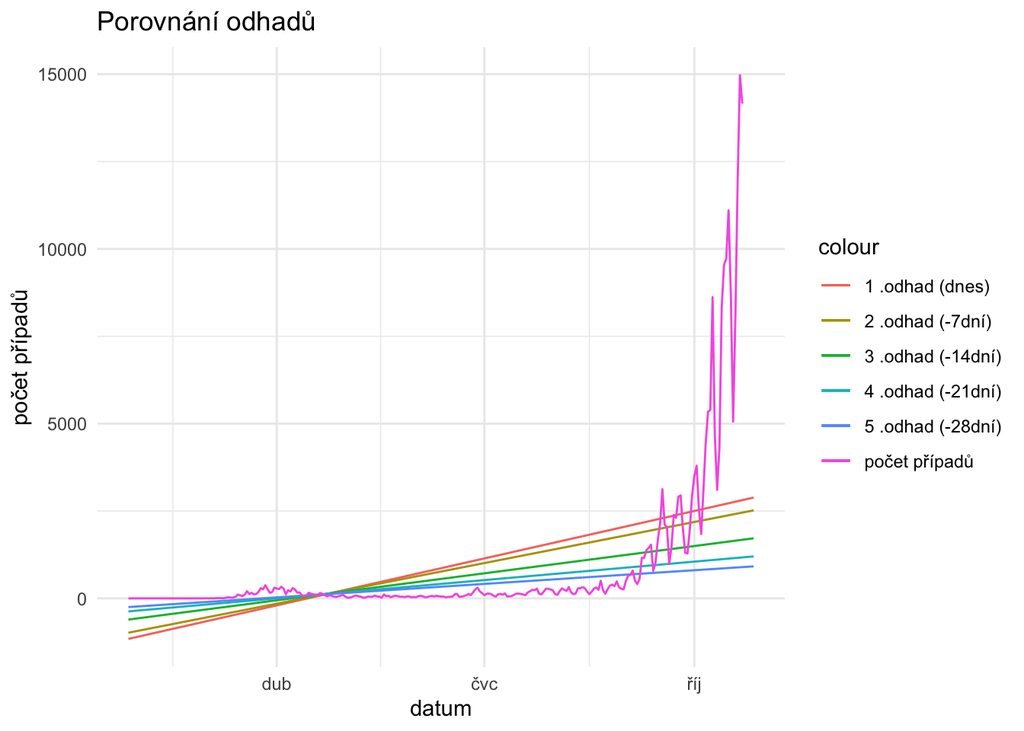

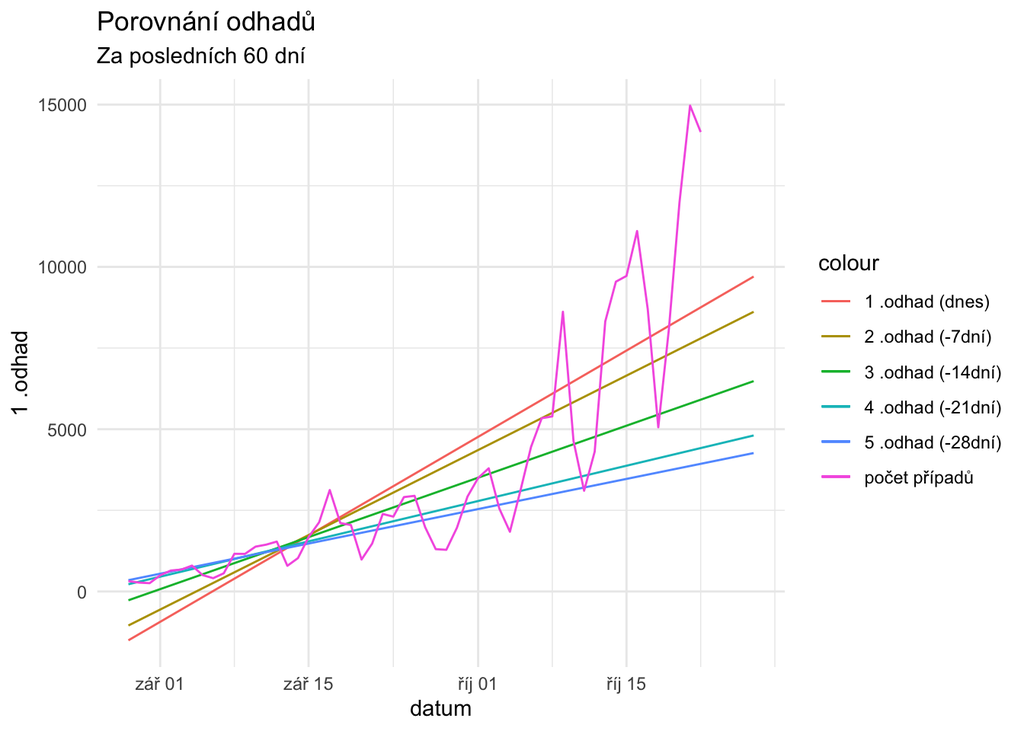

### Data (Lineární model)

#### Od začátku epidemie

Podle lineárního modelu bychom tímto tempem měli dne `2020-10-27` podle

- 1. odhadu `2884` nakažených denně
- 2. odhadu `2519` nakažených denně
- 3. odhadu `1719` nakažených denně
- 4. odhadu `1201` nakažených denně
- 5. odhadu `916` nakažených denně

#### Za posledních `60` dní

Podle lineárního modelu bychom tímto tempem měli dne `2020-10-27` podle

- 1. odhadu `9702` nakažených denně
- 2. odhadu `8616` nakažených denně
- 3. odhadu `6481` nakažených denně
- 4. odhadu `4806` nakažených denně
- 5. odhadu `4265` nakažených denně

## Kvadratický model

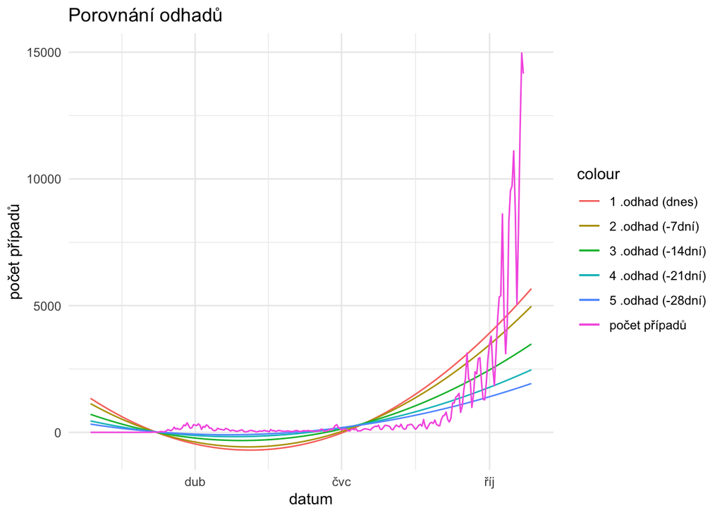

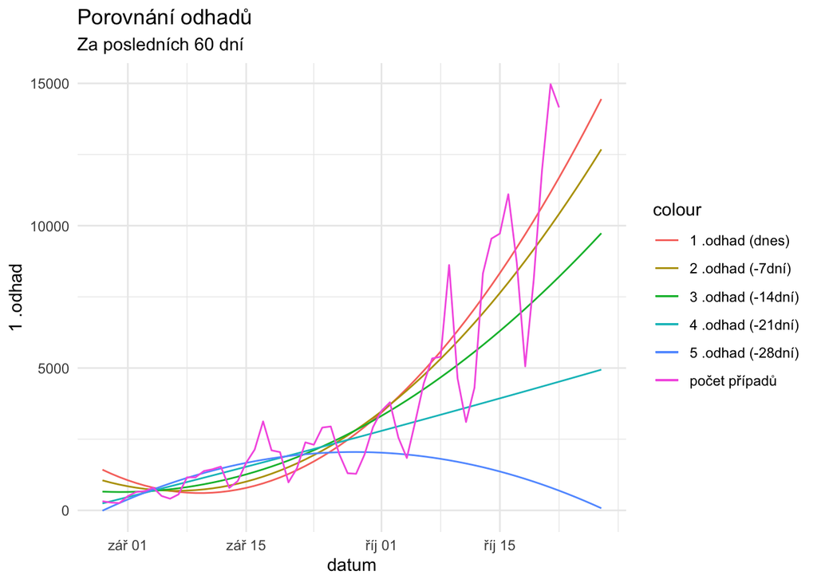

### Data (Kvadratický model)

#### Od začátku epidemie

Podle kvadratického modelu bychom tímto tempem měli dne `2020-10-27` podle

- 1. odhadu `5671` nakažených denně
- 2. odhadu `4976` nakažených denně
- 3. odhadu `3486` nakažených denně
- 4. odhadu `2469` nakažených denně
- 5. odhadu `1927` nakažených denně

#### Za posledních `60` dní

- 1. odhadu `14449` nakažených denně
- 2. odhadu `12680` nakažených denně
- 3. odhadu `9734` nakažených denně
- 4. odhadu `4942` nakažených denně
- 5. odhadu `76` nakažených denně

## Exponential model

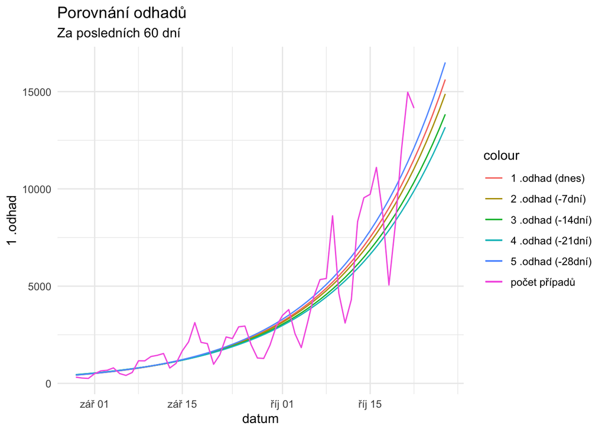

### Data (Exponential model)

#### Za posledních `60` dní

Podle exponencionálního modelu bychom tímto tempem měli dne `2020-10-27` podle

- 1. odhadu `15624` nakažených denně
- 2. odhadu `14883` nakažených denně
- 3. odhadu `13835` nakažených denně
- 4. odhadu `13172` nakažených denně
- 5. odhadu `16502` nakažených denně

Podle exponencionálního modelu bychom tímto tempem měli dnes dne `2020-10-23` podle

- 1. odhadu `12239` nakažených denně
- 2. odhadu `11713` nakažených denně
- 3. odhadu `10960` nakažených denně
- 4. odhadu `10478` nakažených denně
- 5. odhadu `12880` nakažených denně

# SIR MODELY

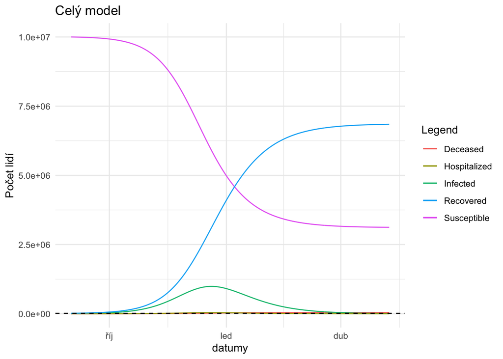

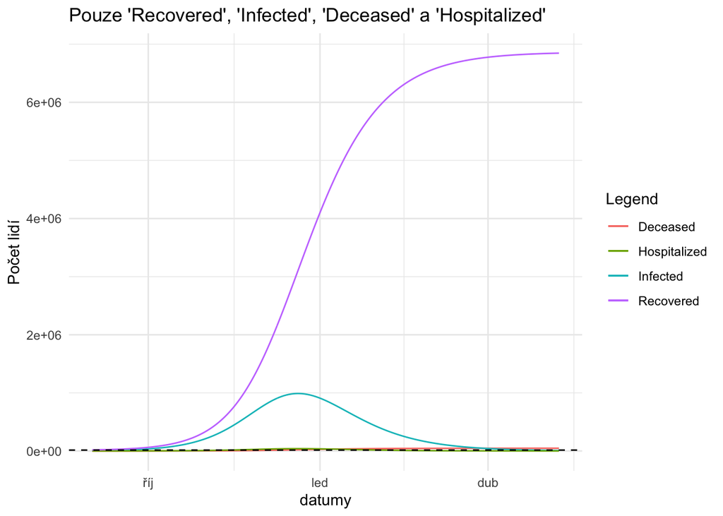

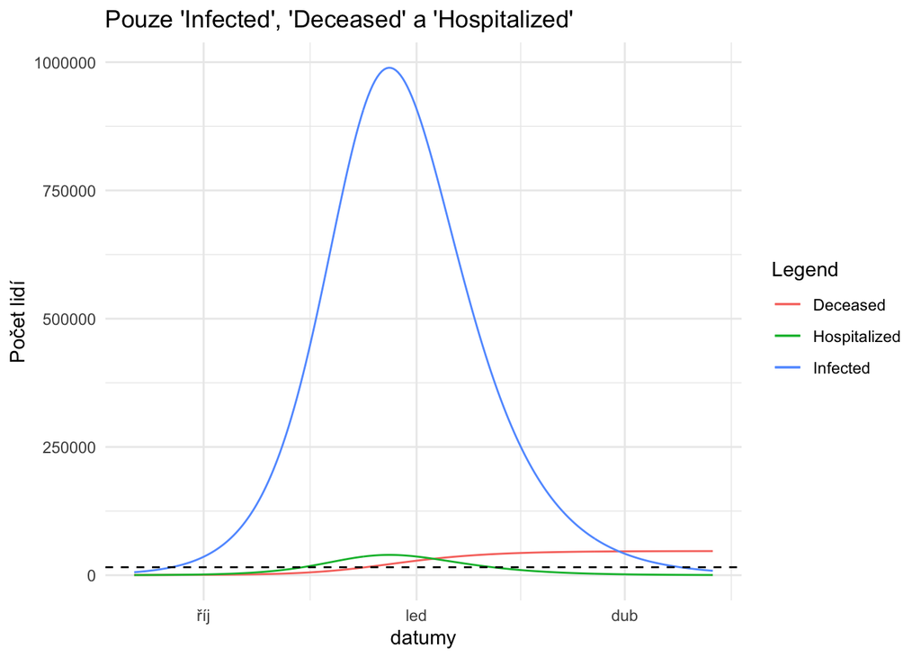

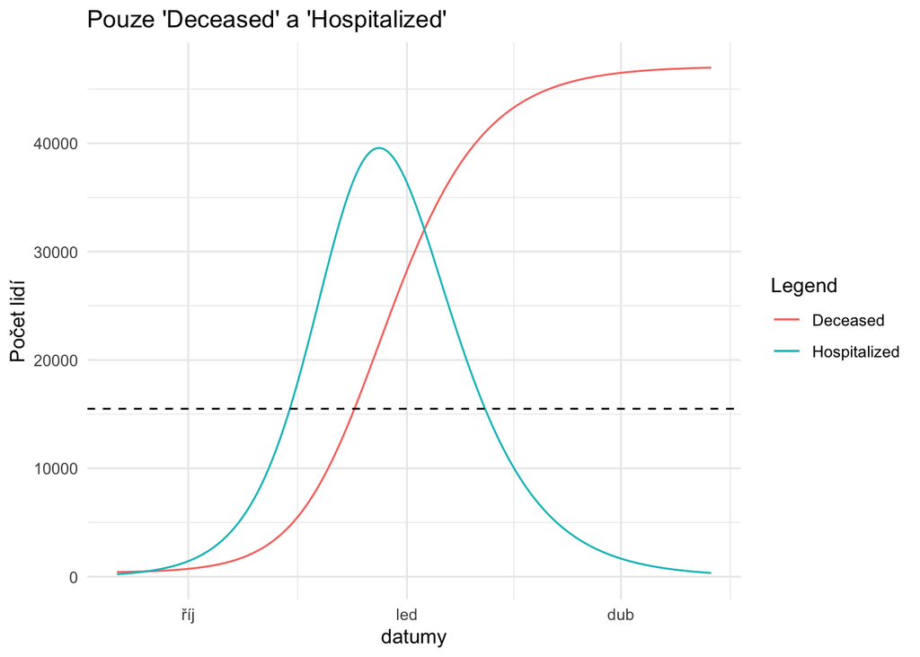

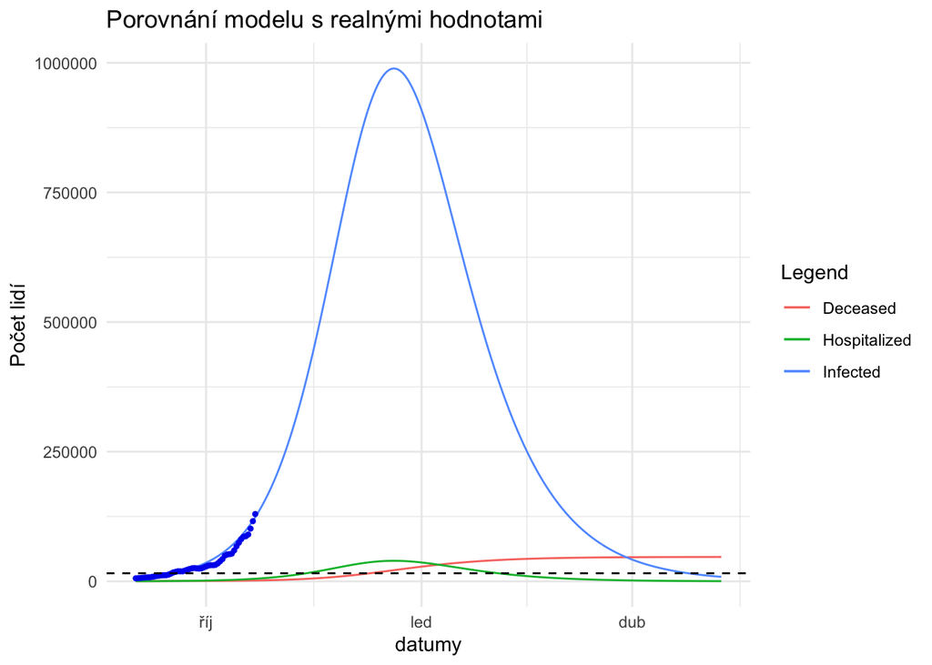

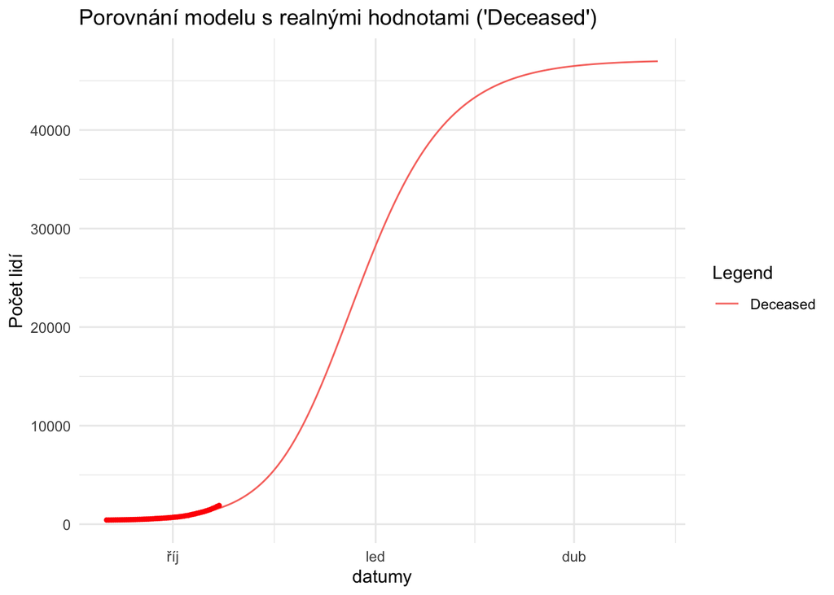

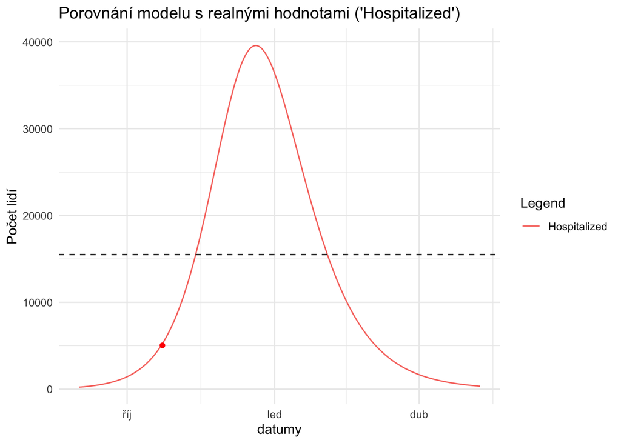

## Informace

`Peak nastane dne 2020-12-20 s počtem nakažených rovnu 989166 a aktuálním počtem hospitalizovných v nemocnicích 39567 lidí.`

`Kapacita nemocnic, která je stanovena na 15500 lůžek, bude při momentálním trendu překročena dne 2020-11-13`

`Celkově Covid-19 prodělá 6846520`

`Počet umrtí se zastaví na čísle 46980`

`Momentální hodnota rho je 1.705`

# Informace

Update proběhl `2020-10-23 18:54:40`.

Poslední data jsou z `2020-10-22` ze stránek ministerstva zdravotnictví ČR (https://onemocneni-aktualne.mzcr.cz/covid-19)